# CPP 516: Hebert Final Project

# Community Demographics

```r
these.variables <- c("pnhwht12", "pnhblk12", "phisp12", "pntv12", "pfb12", "polang12",
"phs12", "pcol12", "punemp12", "pflabf12", "pprof12", "pmanuf12",
"pvet12", "psemp12", "hinc12", "incpc12", "ppov12", "pown12",
"pvac12", "pmulti12", "mrent12", "mhmval12", "p30old12", "p10yrs12",
"p18und12", "p60up12", "p75up12", "pmar12", "pwds12", "pfhh12")


# replace these with descriptive labels
# from the data dictionary

these.labels <- c("Percent White, non-Hispanic", "Percent Black, non-Hispanic", "Percent Hispanic", "Percent Native American race", "Percent foreign born", "Percent speaking other language at home, age 5 plus", "Percent with high school degree or less", "Percent with a 4-year college degree or more", "Percent unemployed", "Percent female labor force participation", "Percent professional employees", "Percent manufacturing employees", "Percent veteran", "Percent self-employed", "Median HH income, total", "Per capita income", "Percent in poverty total", "Percent owner-occupied units", "Percent vacant units", "Percent multi-family units", "Median rent", "Median home value", "Percent structures more than 30 years old", "Percent HH in neighborhood 10 years or less", "Percent 17 and under total", "Percent 60 and older, total", "Percent 75 and older total", "Percent currently married, not separated", "Percent widowed, divorced and separated", "Percent female-headed families with children")

x <- these.labels
names(x) <- these.variables

radioButtons( inputId ="demographics",
              label = h3("Census Variables"),
              choiceNames = these.labels,
              choiceValues = these.variables,
              selected = "pnhwht12")
```

### Census Variables

Percent White, non-Hispanic

Percent Black, non-Hispanic

Percent Hispanic

Percent Native American race

Percent foreign born

Percent speaking other language at home, age 5 plus

Percent with high school degree or less

Percent with a 4-year college degree or more

Percent unemployed

Percent female labor force participation

Percent professional employees

Percent manufacturing employees

Percent veteran

Percent self-employed

Median HH income, total

Per capita income

Percent in poverty total

Percent owner-occupied units

Percent vacant units

Percent multi-family units

Median rent

Median home value

Percent structures more than 30 years old

Percent HH in neighborhood 10 years or less

Percent 17 and under total

Percent 60 and older, total

Percent 75 and older total

Percent currently married, not separated

Percent widowed, divorced and separated

Percent female-headed families with children

```r
# Adding interpretable variable names
# from the data dictionary:
# add a name attribute for each variable
#
# value <- c(1,2,3)
# dd.name <- c("one","two","three")
#
# x <- dd.name
# names(x) <- value
#
# dd names and values linked
# names( x[2] )
#
# can now get the label using the value
# using the name attributes
# x[ "two" ]
#
# to add labels to the maps
# use the radio button value
# to get the data dictionary label:
#
# x[ input$demographics ]
```

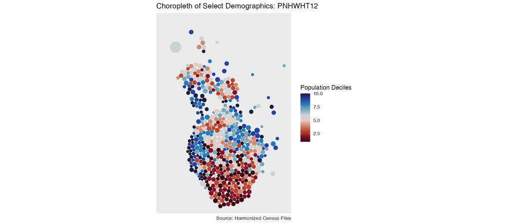

```r
renderPlot({

# split the selected variable into deciles

get_data <-
  reactive({
             sd.sf <-
             sd.sf %>%
             mutate( q = ntile( get(input$demographics), 10 ) )
          })


ggplot( get_data() ) +
    geom_sf(  aes( fill = q ), color=NA ) +
    coord_sf( datum=NA ) +
    labs( title = paste0( "Choropleth of Select Demographics: ", toupper(input$demographics) ),
          caption = "Source: Harmonized Census Files",
          fill = "Population Deciles" ) +
    scale_fill_gradientn( colours=rev(ocean.balance(10)), guide = "colourbar" ) +
      xlim( xmin = -117.5, xmax = -116.7) + #using proper san diego coordinates
      ylim( ymin = 32.5, ymax = 33.5)

})
```

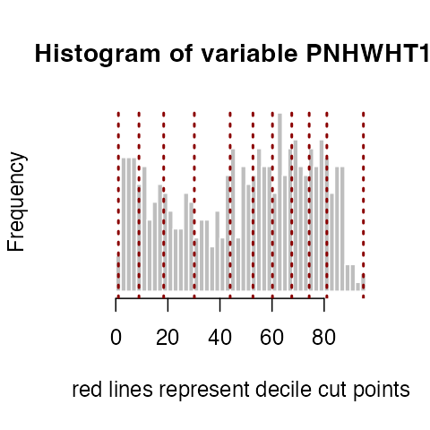

```r
renderPlot({

# extract vector x from the data frame
# x <-  d[ "pnhwht12" ] %>% unlist()


get_variable_x <- reactive({ d[ input$demographics ] })

x <- get_variable_x() %>% unlist()

cut.points <- quantile( x, seq( 0, 1, 0.1 ) )

hist( x, breaks=50,
      col="gray", border="white", yaxt="n",
      main=paste0( "Histogram of variable ", toupper( input$demographics ) ),
      xlab="red lines represent decile cut points" )

abline( v=cut.points, col="darkred", lty=3, lwd=2 )


})
```

# Neighborhoods

```r
#rewriting cartogram to file with clusters (did not save with clusters before)

#sd_dorling <- spTransform( sd_dorling, CRS("+proj=longlat +datum=WGS84") )
#geojson_write( sd_dorling, file="sd_dorling.geojson", geometry="polygon" )

sd2 <- sd_dorling
```

```r
# define the bounding box corners
bb <- st_bbox( c( xmin = -117.50000, xmax = -116.70000,
                  ymin = 32.50000, ymax = 33.50000 ))

               ##crs = st_crs("+init=epsg:3395")) #removing CRS conversion


# ADD YOUR CUSTOM LABELS TO THE CLUSTERS
#unique(sd_dorling$cluster)
sd2$cluster[ sd2$cluster == "1" ] <- "Diverse, Middle Class, Older Veterans"
sd2$cluster[ sd2$cluster == "2" ] <- "Single Professionals, New Construction"
sd2$cluster[ sd2$cluster == "3" ] <- "Diverse, Low Education, High Poverty"
sd2$cluster[ sd2$cluster == "4" ] <- "Wealthy Older White"
sd2$cluster[ sd2$cluster == "5" ] <- "Foreign Born Hispanic with Children"
sd2$cluster[ sd2$cluster == "6" ] <- "Married High Income Professionals"



renderTmap({

tmap_mode("view")
tm_basemap( "CartoDB.Positron" )
tm_shape( sd2, bbox=bb ) +
  tm_polygons( col="cluster", palette="Accent",
               title="Community Types" )

})
```

[interactive chart not shown]

# NH Change 2000-2010

```r
button.values <- c("mhv.00","mhv.10","mhv.change","mhv.growth")

button.labels <- c("Median Home Value 2000","Median Home Value 2010","Value Change 2000-2010","Growth in Home Value")

#added below in to mimic first tab
x <- button.labels
names(x) <- button.values

radioButtons( inputId="home.value",
              label = h3("Home Values"),
              # choices = these.variables,
              choiceNames=button.labels,
              choiceValues=button.values,
              selected="mhv.00")
```

### Home Values

Median Home Value 2000

Median Home Value 2010

Value Change 2000-2010

Growth in Home Value

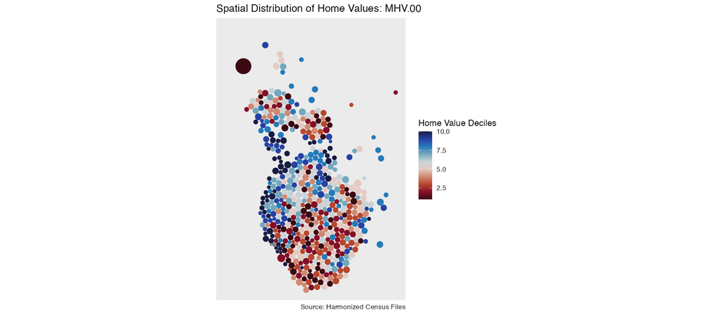

```r
renderPlot({

# split the selected variable into deciles

get_data <-
  reactive({
             sd.sf <-
             sd.sf %>%
             mutate( q = ntile( get(input$home.value), 10 ) )
          })

#chat gpt updated code
  ggplot(get_data()) +
    geom_sf(aes(fill = q), color = NA) +
    coord_sf(datum = NA) +
    labs(
      title = paste0("Spatial Distribution of Home Values: ", toupper(input$home.value)),
      caption = "Source: Harmonized Census Files",
      fill = "Home Value Deciles" #legend title
    ) +
    scale_fill_gradientn(colours = rev(ocean.balance(10)), guide = "colourbar") +
    xlim(xmin = -117.5, xmax = -116.7) + # adjusted to proper San Diego coordinates
    ylim(ymin = 32.5, ymax = 33.5)

})
```

```r
#original code
# ggplot( get_data() ) +
#     geom_sf( aes( fill = q ), color=NA ) +
#     coord_sf( datum=NA ) +
#     labs( title = paste0( "Spatial Distribution of Home Values: ", toupper(input$home.value) ), #changed input id from demo to home value
#           caption = "Source: Harmonized Census Files",
#           fill = "Home Value Deciles" )
#     scale_fill_gradientn( colours=rev(ocean.balance(10)), guide = "colourbar" ) +
#      xlim( xmin = -117.5, xmax = -116.7) + #adjusted to proper san diego coordinates
#     ylim( ymin = 32.5, ymax = 33.5)
```

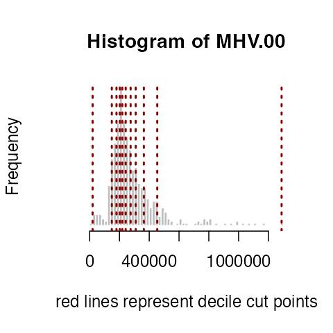

```r
renderPlot({

# extract vector x from the data frame
# x <-  d[ "pnhwht12" ] %>% unlist()

get_variable_x <- reactive({ d[ input$home.value ] })

x <- get_variable_x() %>% unlist() %>% as.numeric()

cut.points <- quantile( x, seq( 0, 1, 0.1 ), na.rm = TRUE )

hist( x, breaks=50,
      col="gray", border="white", yaxt="n",
      main=paste0( "Histogram of ", toupper( input$home.value ) ),
      xlab="red lines represent decile cut points" )

abline( v=cut.points, col="darkred", lty=3, lwd=2 )


})
```

# Drivers of Change

```r
button.labels <- c("Median Home Value 2000","Median Home Value 2010","Value Change 2000-2010","Growth in Home Value")
button.values <- c("mhv.00","mhv.10","mhv.change","mhv.growth")

radioButtons( inputId="dv",
              label = h3("Select Your Dependent Variable"),
              choiceNames=button.labels,
              choiceValues=button.values,
              selected="mhv.change")
```

### Select Your Dependent Variable

Median Home Value 2000

Median Home Value 2010

Value Change 2000-2010

Growth in Home Value

```r
covariates <- c("pnhwht12", "pnhblk12", "phisp12", "pntv12", "pfb12", "polang12",
"phs12", "pcol12", "punemp12", "pflabf12", "pprof12", "pmanuf12",
"pvet12", "psemp12", "hinc12", "incpc12", "ppov12", "pown12",
"pvac12", "pmulti12", "mrent12", "mhmval12", "p30old12", "p10yrs12",
"p18und12", "p60up12", "p75up12", "pmar12", "pwds12", "pfhh12")

covariate.labels <- c("Percent White, non-Hispanic", "Percent Black, non-Hispanic", "Percent Hispanic", "Percent Native American race", "Percent foreign born", "Percent speaking other language at home, age 5 plus", "Percent with high school degree or less", "Percent with a 4-year college degree or more", "Percent unemployed", "Percent female labor force participation", "Percent professional employees", "Percent manufacturing employees", "Percent veteran", "Percent self-employed", "Median HH income, total", "Per capita income", "Percent in poverty total", "Percent owner-occupied units", "Percent vacant units", "Percent multi-family units", "Median rent", "Median home value", "Percent structures more than 30 years old", "Percent HH in neighborhood 10 years or less", "Percent 17 and under total", "Percent 60 and older, total", "Percent 75 and older total", "Percent currently married, not separated", "Percent widowed, divorced and separated", "Percent female-headed families with children")

checkboxGroupInput( inputId="covariates",
              label = h3("Select Variables for Your Model"),
              ##choices = covariates,
              choiceNames=covariate.labels,
              choiceValues=covariates,
              selected=c("pnhwht12","pprof12","pvac12") )
```

### Select Variables for Your Model

Percent White, non-Hispanic

Percent Black, non-Hispanic

Percent Hispanic

Percent Native American race

Percent foreign born

Percent speaking other language at home, age 5 plus

Percent with high school degree or less

Percent with a 4-year college degree or more

Percent unemployed

Percent female labor force participation

Percent professional employees

Percent manufacturing employees

Percent veteran

Percent self-employed

Median HH income, total

Per capita income

Percent in poverty total

Percent owner-occupied units

Percent vacant units

Percent multi-family units

Median rent

Median home value

Percent structures more than 30 years old

Percent HH in neighborhood 10 years or less

Percent 17 and under total

Percent 60 and older, total

Percent 75 and older total

Percent currently married, not separated

Percent widowed, divorced and separated

Percent female-headed families with children

```r
# RUNNING A REGRESSION WITH USER INPUTS
#
# create a formula object
# by constructing the formula from user selections
# as a string then casting as a formula object
# x.s <- c("x1","x2","x3" )
# formula.text <- paste( "y", " ~ ", paste0( x.s, collapse=" + ") )
# formula.object <- as.formula( formula.text )
#
# lm( formula.object, data=d )
#
# make sure all variables are in d



# check boxes return vectors
get_covariates <-  reactive({ input$covariates })
get_DV <-  reactive({ input$dv })


renderUI({

covariates <- get_covariates()
dv <- get_DV()

formula.text <- paste0(dv, " ~ ", paste( covariates, collapse=" + " ) )
fo <- as.formula( formula.text )

m <- lm( fo, data=d )


# HTML( "<div style='width: 60%; margin: 0px auto;'>" )
HTML(

  c("<br><br><br>",
  "<div type='regression' style='width: 60%; margin: 0px auto;'>",
  stargazer( m, type="html", omit.stat=c("rsq","f") ),
  "</div>",
  "<br><br><br>"
  )

  )


})
```

|  | *Dependent variable:* |
| --- | --- |
|  | mhv.change |
| pnhwht12 | 632.874*** |
|  | (192.798) |
| pprof12 | 1,276.164*** |
|  | (299.237) |
| pvac12 | -1,378.267** |
|  | (627.211) |
| Constant | 60,742.670*** |
|  | (9,436.222) |
| Observations | 534 |
| Adjusted R<sup>2</sup> | 0.174 |
| Residual Std. Error | 78,381.700 (df = 530) |
| *Note:* | *p<0.1; **p<0.05; ***p<0.01 |

```r
# HTML( reg.table )
```

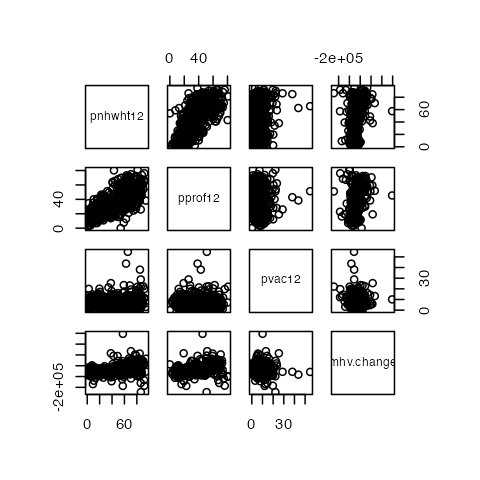

```r
renderPlot({

selected_data <- sd2[, c(input$covariates, input$dv), drop = FALSE]

pairs(selected_data)

})
```